# Bebés en Toluca

Jorge Salvador Ruiz Montaño

22/11/2020

## Sección A

### A.1 Bebés

1. Para cada AGEB del Municipio de Toluca, estima cuántos bebés de 0 a 6 meses de edad habitan ahí el día de hoy. Explica tu razonamiento en menos de 300 palabras. Enlista tus fuentes y presenta resultados.
- Primero vamos a utilizar una base de datos del estado de México. **Link:** https://salud.edomex.gob.mx/isem/dis_n_proy_conapo.
- Estos datos miden los nacimientos en el estado de México, hay varias bases de datos por año, pero a nosotros nos interesa utilizar la base **Por municipio y lugar de nacimiento**, ya que en ésta se listan todos los municipios (incluido Toluca que es el que nos interesa).
- Extrajimos los datos de Toluca y los colocamos en un Excel que nombramos: toluca_nacimientos.xlsx
- Además usamos los datos de Censo de Población y vivienda 2010, de donde se extrajeros los datos de población de Toluca por AGEB. **Link:** https://www.inegi.org.mx/programas/ccpv/2010/default.html#Datos_abiertos

### Tabla Nacimientos de Toluca por Año (2008-2014)

| Año | Municipio | Lugar de Nacimiento Secretaria de Salud | Lugar de Nacimiento IMSS Oportunidades | Lugar de Nacimiento IMSS | Lugar de Nacimiento ISSSTE | Lugar de Nacimiento PEMEX | Lugar de Nacimiento SEDENA | Lugar de Nacimiento SEMAR | Lugar de Nacimiento Otra unidad Pública | Lugar de Nacimiento Unidad Médica Privada | Lugar de Nacimiento Vía Pública | Lugar de Nacimiento Hogar | Lugar de Nacimiento Otro Lugar | Lugar de Nacimiento No especificado | Total General |
| --- | --- | --- | --- | --- | --- | --- | --- | --- | --- | --- | --- | --- | --- | --- | --- |
| 2014 | Toluca | 12,818 | 1 | 6522 | 445 | 0 | 0 | 0 | 12226 | 4381 | 2 | 53 | 0 | 0 | 36448 |
| 2013 | Toluca | 12,828 | 2 | 6888 | 408 | 0 | 0 | 0 | 13223 | 4309 | 2 | 53 | 1 | 0 | 37714 |
| 2012 | Toluca | 12,576 | 0 | 9480 | 75 | 0 | 1 | 0 | 13840 | 4794 | 1 | 78 | 1 | 0 | 40846 |
| 2011 | Toluca | 11,605 | 1 | 9685 | 0 | 0 | 0 | 0 | 13744 | 4888 | 2 | 93 | 9 | 0 | 40027 |
| 2010 | Toluca | 12,946 | 1 | 8890 | 118 | 0 | 0 | 0 | 12927 | 4806 | 0 | 87 | 9 | 3 | 39787 |
| 2009 | Toluca | 11,882 | 1 | 10026 | 543 | 0 | 0 | 2 | 13774 | 4903 | 4 | 130 | 8 | 0 | 41273 |
| 2008 | Toluca | 9,635 | 1 | 11050 | 661 | 0 | 0 | 4 | 12937 | 5327 | 4 | 176 | 15 | 0 | 39810 |

## Gráfica de Nacimientos por Año

Podemos observar como han fluctuado los nacimientos totales por año en Toluca

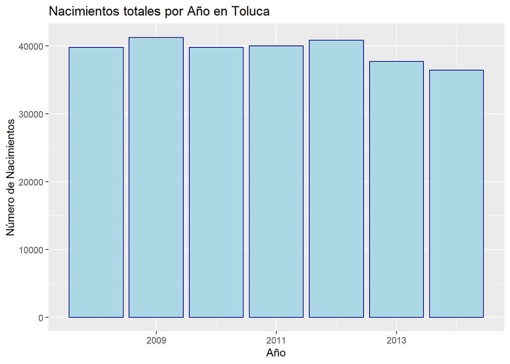

## Cálculo de los nacimientos a nivel Toluca (Total)

- Primero se calculó el promedio de nacimientos por año, que resultó: **39415**
- Por lo que el promedio de nacimientos por mes fue: **3284.6**

- Para ello obtenemos los totales por AGEB de Toluca, los comparamos con los nacimientos promedio y obtenemos el resultado aproximado.
- Para ver los detalles del cálculo y manejo de datos puede consultar el código de R.

| AGEB | Número niños de 0 a 6 meses |
| --- | --- |
| 307 | 74.1 |
| 330 | 85.9 |
| 345 | 52.5 |
| 035A | 132.0 |
| 379 | 122.2 |
| 383 | 52.0 |
| 398 | 36.3 |
| 400 | 49.1 |
| 415 | 38.8 |
| 042A | 51.5 |
| 434 | 48.6 |
| 449 | 65.8 |
| 453 | 27.5 |
| 468 | 50.6 |
| 472 | 11.8 |
| 487 | 54.5 |
| 491 | 43.2 |
| 504 | 61.3 |
| 519 | 16.2 |
| 523 | 46.1 |
| 538 | 23.6 |
| 542 | 28.5 |
| 557 | 57.9 |
| 561 | 115.3 |
| 576 | 43.7 |
| 580 | 10.3 |
| 595 | 20.6 |
| 608 | 50.6 |
| 631 | 48.6 |
| 646 | 132.5 |

[output cut: 226 more lines]